# Differences in Color Perception

Author

Ilana Berlin

Published

September 22, 2025

```r
library(tidyverse)
library(gt)
survey_results <- read_csv("color_survey.csv")
```

```r
filtered_results <- survey_results %>%
  filter(!is.na(colorblind)) %>%
  mutate(colorblind = case_when( #convert to actual values
   colorblind == 1 ~ "Colorblind",
   colorblind == 0 ~ "Trichromatic"),
  y_chromosome = case_when(
    y_chromosome == 1 ~ "Yes",
    y_chromosome == 0 ~ "No"
  )) %>%
  select(user_id,
         response,
         y_chromosome,
         colorblind,
         color) %>%
  arrange(user_id)
```

Humans percive color via red (L-), blue (S-), and green (M-) cones in the eye.[^1] The function of these color receptors impact how people perceive colors. People with trichromatic vision have all three receptors functioning and people who are colorblind have a lack of or reduced use of one or more receptors. Comparing differences in `colorblind` from the 2010 xkcd color survey can give some insight into differences in color perception.[^2]

3,550 users neglected to report the state of their vision (if they were colorblind or not) therefore, 76,212 responses from these users had to be excluded. In total there were 2,636 respondants who were colorblind and 65,503 who had trichromatic vision.

```r
filtered_results %>% group_by(user_id) %>%
  summarize("Vision" = first(colorblind)) %>%
  ungroup() %>%
  group_by(Vision) %>%
  summarise(Count = n()) %>%
  gt() %>%
  tab_header("Number of Respondants by Vision Type")
```

Number of Respondants by Vision Type

| Vision | Count |
| --- | --- |
| Colorblind | 2636 |
| Trichromatic | 65503 |

### Color Perception is Genetic

Genetic mutations can change the functions of these cones. People with a `Y chromosome` are more likely to have colorblindness because they only need their one X chromosome to have a mutation in order for it to express.[^3] This is reflected in the data from the color survey.

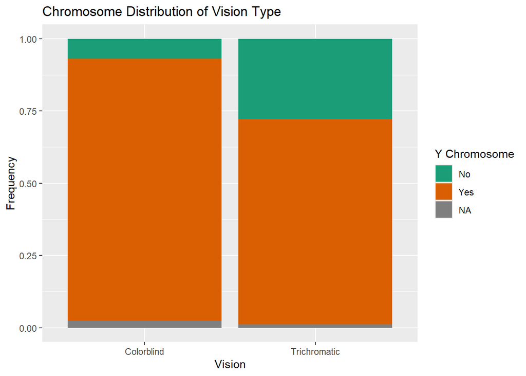

```r
filtered_results %>%
  group_by(user_id) %>%
  summarise(colorblind = first(colorblind),
            y_chromosome = first(y_chromosome)) %>%
  ggplot(aes(x = colorblind,
            fill = y_chromosome)) +
  geom_bar(position = "fill") +
  labs(x = "Vision",
       y = "Frequency",
       title = "Chromosome Distribution of Vision Type",
       fill = "Y Chromosome") +
  scale_fill_brewer(palette = "Dark2",
                    na.value = "grey50")
```

### Seeing Fewer Colors Makes Colors More Repetative

Colorblindness can limit the number of colors a person can perceive.[^4] This increases the number of times that people put common responses. The top five most common responses capture a larger percent of the responses from colorblind respondents than trichromatic respondents.

```r
filtered_results %>%
  select(colorblind,
         Response = response) %>%
  group_by(colorblind,
           Response) %>%
  summarise(count = n()) %>%
  arrange(desc(count)) %>%
   pivot_wider(names_from = colorblind,
              values_from = count,
              values_fill = 0) %>%
  head(n = 5) %>%
  mutate(Trichromatic = round((Trichromatic / 1654306   ) * 100, 2), #divide by the total number of trichromatic responses
         Colorblind = round((Colorblind / 66418) * 100, 2)) %>% #divide by the total number of colorblind responses
  gt() %>%
  tab_header("Percent of Five Most Common Responses")
```

Percent of Five Most Common Responses

| Response | Trichromatic | Colorblind |
| --- | --- | --- |
| green | 9.08 | 13.11 |
| blue | 8.26 | 11.74 |
| purple | 7.37 | 7.00 |
| pink | 3.72 | 6.54 |
| brown | 2.18 | 3.00 |

> This is not completly accurate as values may be unaccounted for due to spelling errors, capitaliztion, and additional words and symbols.

The table below provides an example of the responses from trichromatic respondent `104` and colorblind respondent `218`, the first people I found within each vision group who looked at exactly 10 colors. While `blue` appears multiple times for both respondents, `blue` and `green`, two of the top most common responses, appear more frequently from the colorblind respondent.

```r
example_results <- filtered_results %>%
  filter(user_id == 104 |
           user_id == 218) %>%
  select(colorblind,
         "Response" = response,
         "Color" = color) %>%
  arrange(colorblind) %>%
  group_by(colorblind) %>%
  arrange(Response) %>%
  mutate(row = row_number()) %>%
  ungroup() %>%
    pivot_wider(names_from = colorblind,
              values_from = c(Response, Color),
              names_sep = "_")

example_results %>%
  select(contains("Trichromatic"),
         contains("Colorblind")) %>%
  gt() %>%
  data_color(columns = Color_Trichromatic, #with the help of Google and Claude
    target_columns = c(Response_Trichromatic, Color_Trichromatic),
    fn = identity) %>%
  data_color(columns = Color_Colorblind,
    target_columns = c(Response_Colorblind, Color_Colorblind),
    fn = identity) %>%
  tab_header(title = "Sample of Colors and responses from trichromatic and colorblind respondant")
```

Sample of Colors and responses from trichromatic and colorblind respondant

| Response_Trichromatic | Color_Trichromatic | Response_Colorblind | Color_Colorblind |
| --- | --- | --- | --- |
| blue | #6468cd | blue | #316dd3 |
| blue | #1258b2 | blue | #6b6c91 |
| burgundy | #832e46 | blue | #b249a1 |
| forest | #2eb529 | green | #6ece07 |
| green | #36d679 | green | #aa6d34 |
| lavendar | #cba1dd | green | #b89c2b |
| navy | #462a92 | green | #06db08 |
| olive | #6eb559 | lavender | #a8b4f8 |
| soot | #4f364b | purple | #b13ba8 |
| wine | #900964 | sea green | #2fe4a4 |

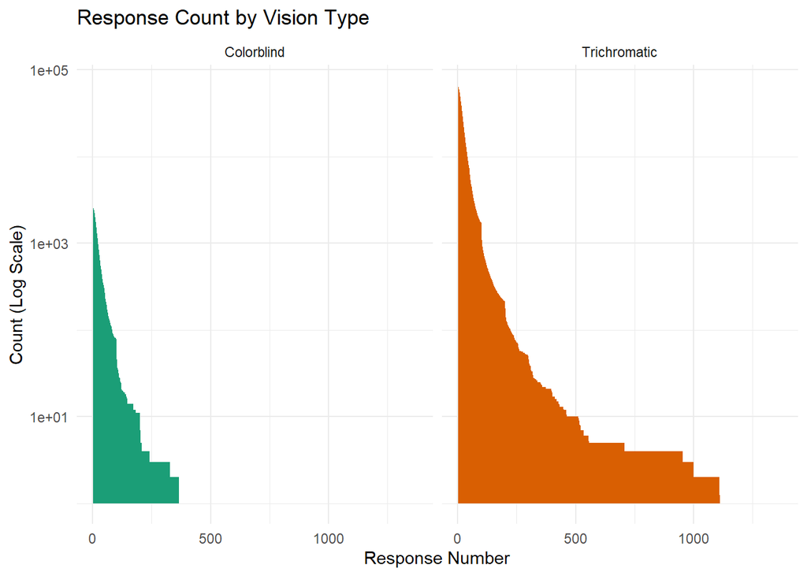

```r
filtered_results %>%
  group_by(user_id) %>%
  mutate(response_num = row_number()) %>%
  ungroup() %>%
  group_by(colorblind,
           response_num) %>%
  summarise(count = n()) %>%
  ggplot(aes(x = response_num,
             y = count,
             fill = colorblind)) +
  facet_wrap(~ colorblind) +
  geom_area(show.legend = FALSE) +
  scale_y_log10() +
  theme_minimal() +
  labs(title = "Response Count by Vision Type",
       x = "Response Number",
       y = "Count (Log Scale)") +
  scale_fill_brewer(palette = "Dark2")
```

Respondents with trichromatic vision blamed their limited participation on colorblindness more often then ones that actually were colorblind. They cited colorblindness more frequently when struggling to come up with a response for a color.

```r
filtered_results %>%
  filter(str_detect(response, "colorblind") & #found from textbook
           !str_detect(response, "INSERT")) %>%
  select(Response = response,
         colorblind,
         Color = color) %>%
  group_by(colorblind) %>%
  summarise(Response,
            Color) %>%
  arrange(Color) %>%
  gt(row_group_as_column = TRUE) %>%
  data_color(columns = Color,
    target_columns = c(Response, Color),
    fn = identity) %>%
  tab_header("Responses including 'colorblind'")
```

Responses including 'colorblind'

|  | Response | Color |
| --- | --- | --- |
| Colorblind | fuck-i-said-i-am-colorblind-stop-green-shit | #04b778 |
|  | something else... im colorblind, give me a break with this... | #3bba8d |
|  | colorblind gray | #c0a7b9 |
|  | why would you do this to someone who is colorblind? | #c9b1e4 |
| Trichromatic | i think i might be colorblind after all, green/brown? | #363f26 |
|  | if i was colorblind it could be green | #446ee1 |
|  | maybe i am colorblind green | #6d8c49 |
|  | i have gone colorblind | #80e1d0 |
|  | shit...i think i am colorblind | #90c4bd |
|  | im colorblind. | #942634 |
|  | colorblind grey | #9493aa |
|  | colorblindness, eh? | #99ba1d |
|  | seriously? these all look purple, maybe i am colorblind! | #d82a86 |
|  | colorblind pink | #dea1b0 |
|  | maybe i am colorblind... | #feca6a |

## Footnotes

[^1]: [Nickerson. C: The Trichromatic Theory of Color Vision *SimplePsychology* **2023**](https://www.simplypsychology.org/what-is-the-trichromatic-theory-of-color-vision.html)
[^2]: [Randall: Color Survey Results *xkcd* **2010**](https://blog.xkcd.com/2010/05/03/color-survey-results/)
[^3]: [Causes of Color Vision Deficiency *National eye Institute* **2025**](https://www.nei.nih.gov/learn-about-eye-health/eye-conditions-and-diseases/color-blindness/causes-color-vision-deficiency)
[^4]: [What Do Color Blind People See? *Enchroma*](https://enchroma.com/blogs/beyond-color/how-color-blind-see)